# Main Model Assessment

Omar Abdullah Gill

April 22, 2026

```r
# Import original data
d <- data.frame(
study = c("Huang, 2022", "Lustgarten, 2015", "Upadhyay, 2019", "Vinther, 2021",

            "Pujol-Lopez, 2022", "Vijayaraman, 2023", "Wang, 2022", "PhysioSync-HF Trial, 2026", "CONSYST-CTR Trial, 2025"),
subgroup = c("HBP", "HBP", "HBP", "HBP", "LBAP", "LBAP", "LBAP", "LBAP", "LBAP"),

  # CSP (Conduction System Pacing)
m1 = c(107.7, 145.0, 125.0, 134.0, 125.0, 137.0, 131.5, 122.0, -49),
sd1 = c(12.5, 24.0, 22.0, 15.0, 18.0, 20.0, 12.5, 25.0, 24),
n1 = c(50, 21, 16, 25, 35, 50, 20, 87, 67),

  # BVP (Biventricular Pacing)
m2 = c(135.7, 165.0, 164.0, 131.0, 129.0, 141.0, 136.6, 126.0, -45),
sd2 = c(16.6, 17.0, 25.0, 20.0, 13.0, 19.0, 12.9, 21.0, 23),
n2 = c(50, 21, 24, 25, 35, 50, 20, 86, 67)

)
# Calculate Mean Difference (MD) and Variance (vi)

d_MD <- escalc(measure = "MD",

                     m1i = m1, sd1i = sd1, n1i = n1,

                     m2i = m2, sd2i = sd2, n2i = n2,

                     data = d) |>
data.frame()

# Calculate Standard Error (sei) from Variance (vi)
d_MD$sei <- sqrt(d_MD$vi)

# View the analyzed dataset
print(d_MD[, c("study", "subgroup", "yi", "vi", "sei")], row.names = FALSE)
```

```
##                      study subgroup    yi       vi      sei
##                Huang, 2022      HBP -28.0  8.63620 2.938741
##           Lustgarten, 2015      HBP -20.0 41.19048 6.417981
##             Upadhyay, 2019      HBP -39.0 56.29167 7.502777
##              Vinther, 2021      HBP   3.0 25.00000 5.000000
##          Pujol-Lopez, 2022     LBAP  -4.0 14.08571 3.753094
##          Vijayaraman, 2023     LBAP  -4.0 15.22000 3.901282
##                 Wang, 2022     LBAP  -5.1 16.13300 4.016591
##  PhysioSync-HF Trial, 2026     LBAP  -4.0 12.31182 3.508820
##    CONSYST-CTR Trial, 2025     LBAP  -4.0 16.49254 4.061101
```

## The model

The Bayesian meta-regression random-effect model is:

$$\begin{align*}
y_i & \sim Normal(\theta_i, \sigma_i^2) \tag{Likelihood} \\
\theta_i & \sim Normal(\mu, \tau^2)\\
\mu & = \alpha_{subgroup[k]}\\
\\
\alpha & \sim \operatorname{Normal}(0, 24.5^2) \tag{Priors} \\
\tau & \sim \operatorname{Half-Normal}(12.5^2) \\
\end{align*}$$

## The Bayesian transperency Checklist

## Diagnostics

As suggested by [Depaoli and van de Schoot, 2017](https://doi.org/10.1037/met0000065) we checked the model fit:

#### “Point 1: Do You Understand the Priors?”

Our goal is to use priors that exclude impossible treatment effects, and yet applies little influence in the final results (hereafter, weakly informative priors).

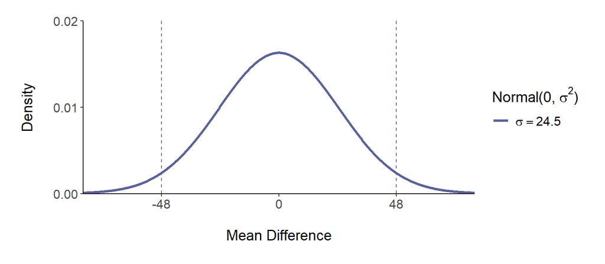

```r
sd_alpha = 24.5
twosd_alpha = sd_alpha * 1.96

# We need a plotting range that fits a distribution with SD = 24.5
# -80 to 80 allows us to see the curve and the 95% interval lines
plot_limit <- 80

ggplot(data = data.frame(x = c(-plot_limit, plot_limit)), aes(x)) +

  # Normal(0, 24.5)
  stat_function(fun = dnorm, n = 1000,
                args = list(mean = 0, sd = sd_alpha),
                linetype = 1,
                linewidth = 1.2, # 'size' is deprecated, 'linewidth' is the modern standard
                aes(colour = "24.5")) +

  # Corrected LaTeX Legend
  scale_colour_manual(name = TeX("Normal(0, $\\sigma^2$)"),
                      values = pnw_palette("Starfish", 3, type = "discrete")[1],
                      labels = TeX(paste0("$\\sigma = ", sd_alpha, "$"))) +

  # 95% Interval vertical lines
  geom_vline(xintercept = c(-twosd_alpha, twosd_alpha),
             linetype = 2,
             color = pnw_palette("Starfish", 3, type = "discrete")[1]) +

  # Adjusted Y-axis: Max density for SD 24.5 is ~0.016
  scale_y_continuous(breaks = seq(0, 0.02, 0.01),
                     limits = c(0, 0.02),
                     expand = c(0, 0)) +

  # Adjusted X-axis to show the full range
  scale_x_continuous(breaks = c(-twosd_alpha, 0, twosd_alpha),
                     labels = function(x) round(as.numeric(x), 1),
                     expand = c(0, 0)) +

  # Zooming out to see the curve
  coord_cartesian(xlim = c(-plot_limit, plot_limit)) +

  labs(x = "\nMean Difference",
       y = "Density\n") +

  theme_classic() +
  theme(
    plot.margin = margin(20, 20, 20, 20),
    axis.text.x = element_text(size = 12),
    axis.text.y = element_text(size = 12),
    axis.title.x = element_text(size = 14),
    axis.title.y = element_text(size = 14),
    legend.position = 'right',
    legend.text = element_text(size = 12),
    legend.title = element_text(size = 14),
    legend.key = element_blank(),
    panel.background = element_blank()
  )
```

95% quantile intervals:

```r
tibble(
  Mean = 0,
  "SD" = sd_alpha,
) %>%
  mutate(

    "Lower_Bound" = Mean - 1.96 * `SD`,
    "Upper_Bound" = Mean + 1.96 * `SD`,
    "95% CI" = str_c("[", round(Lower_Bound, 1), ", ", round(Upper_Bound, 1), "]")
  ) %>%
  # Remove the helper columns before rendering the table
  select(Mean, SD, `95% CI`) %>%
  gt() %>%
  cols_align(
    align = "center",
    columns = everything()
  ) %>%
  tab_spanner(
    label = "Prior Distribution (Mean Difference)",
    columns = everything()
  )
```

| Prior Distribution (Mean Difference) Mean | Prior Distribution (Mean Difference) SD | Prior Distribution (Mean Difference) 95% CI |
| --- | --- | --- |
| 0 | 24.5 | [-48, 48] |

To derive this prior, we first identified a “surprisingly large” effect size for this outcome, 48msec, based on median QRS reduction of the BVP in previous studies. We calculated the scale parameter such that the 97.5th percentile of a normal distribution (mean = 0, standard deviation = “tau_e”) equals this extreme value, and “tau_e” is the 95th percentile of the half-normal prior. The resulting prior has a 97.5th percentile of 48, implying 95% of true study effects range from -48 to 48 mean difference.

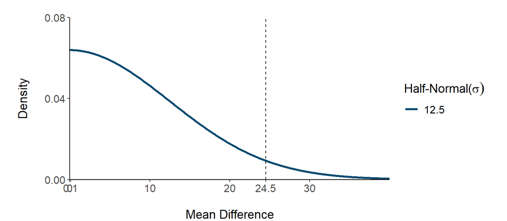

```r
sd_w = 12.5

median_w = round(extraDistr::qhnorm(0.95, sigma = sd_w),2)

# https://stackoverflow.com/questions/19950219/using-legend-with-stat-function-in-ggplot2

ggplot(data = data.frame(x = c(0, 40)), aes(x)) + #Empty plot

  # Half-Normal(0.5)
  stat_function(fun = extraDistr::dhnorm, n = 1000,
              args = list(sigma = sd_w), linetype=1, size = 1.2,
              aes(colour = "12.5")) +

  scale_colour_manual(latex2exp::TeX("Half-Normal($\\sigma)"),
                      values = pnw_palette("Bay", 1, type = "continuous")) +

  scale_y_continuous(breaks = seq(0, 0.08, 0.04),
                     limits = c(0, 0.08),
                     expand = c(0, 0)) + # remove gap between X and Y axis
  scale_x_continuous(breaks = c(0, 0.1,median_w, 20, 10, 30),
                     labels = function(x) round(as.numeric(x), 1),
                     expand = c(0, 0)) +

  geom_vline(xintercept = median_w, linetype = 2) +
  coord_cartesian(x = c(0, 40)) +
  labs(x = "\nMean Difference",
       y = "Density\n") +
  theme_classic() +
  theme(
    plot.margin = margin(20,20,0,20),
    axis.text.x = element_text(size = 12),
    axis.text.y = element_text(size = 12),
    axis.title.x = element_text(size = 14),
    axis.title.y = element_text(size = 14),
    legend.position = 'right',
    legend.text = element_text(size=12),
    legend.title = element_text(size=14),
    legend.key= element_blank(),
    panel.background = element_blank()
    )
```

```r
# Fit the model

## Formula
mf =
  formula(yi | se(sei) ~ 0 + subgroup + (1|study))

priors =
  prior(normal(0, 24.5), class = "b") +
  prior(normal(0, 12.5), class = "sd")

m1 =
  brm(
  data = d_MD,
  family = gaussian,

  formula = mf,
  prior = priors,
  sample_prior = T,

  control = list(adapt_delta = .97),
  backend = "cmdstanr", # faster
  cores = parallel::detectCores(),
  chains = 4,
  warmup = 2000,
  iter = 4000,
  seed = 100)
```

[output not shown]

[output cut: 123 more lines]

```
## Chain 3 finished in 1.6 seconds.
## Chain 2 Iteration: 3800 / 4000 [ 95%]  (Sampling)
## Chain 2 Iteration: 3900 / 4000 [ 97%]  (Sampling)
## Chain 2 Iteration: 4000 / 4000 [100%]  (Sampling)
## Chain 4 Iteration: 3600 / 4000 [ 90%]  (Sampling)
## Chain 4 Iteration: 3700 / 4000 [ 92%]  (Sampling)
## Chain 4 Iteration: 3800 / 4000 [ 95%]  (Sampling)
## Chain 4 Iteration: 3900 / 4000 [ 97%]  (Sampling)
## Chain 4 Iteration: 4000 / 4000 [100%]  (Sampling)
## Chain 2 finished in 1.8 seconds.
## Chain 4 finished in 1.8 seconds.
##
## All 4 chains finished successfully.
## Mean chain execution time: 1.7 seconds.
## Total execution time: 2.0 seconds.
```

```r
# Detailed diagnostics
# launch_shinystan(m1)
```

Prior predictive check:

95% quantile intervals

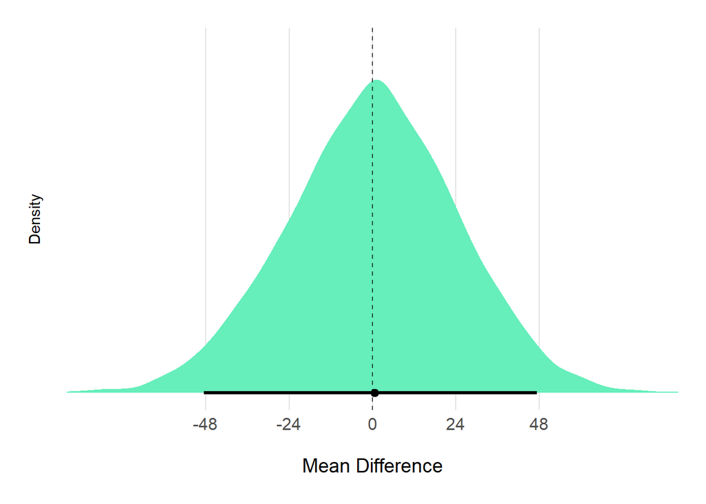

```r
m1 %>%
  prior_draws() %>%
  # Plot!
  ggplot(aes(

    x = b)
  ) +

  # https://mjskay.github.io/ggdist/articles/slabinterval.html
  stat_halfeye(point_interval = median_qi,
               .width = 0.95,
               n = 1e4,
               fill = "#6EB") +

  # Null intercept is 0 for Mean Difference (not 1)
  geom_vline(xintercept = 0, linetype = 2, linewidth = 0.4, alpha = 0.7) +

  labs(
    x = "\nMean Difference",
    y = "Density\n"
  ) +

  # Adjusted breaks to show the 95% range (-48 to 48)
  scale_x_continuous(breaks = c(-48, -24, 0, 24, 48)) +

  # Adjusted zoom to see the full width of your Normal(0, 24.5) prior
  coord_cartesian(xlim = c(-80, 80)) +

  theme(
    strip.background = element_rect(fill = "#E4E6E7"),
    strip.text.x = element_text(size = 12),
    axis.ticks.x = element_blank(),
    axis.ticks.y = element_blank(),
    axis.text.x = element_text(size = 12),
    axis.title.x = element_text(size = 14),
    axis.text.y = element_blank(),
    panel.background = element_blank(),
    panel.grid.major.x = element_line(color = "gray80", linewidth = 0.3),
    legend.position = 'none',
    plot.margin = margin(20, 20, 20, 20))
```

#### “Point 2: Does the Trace-Plot Exhibit Convergence?”

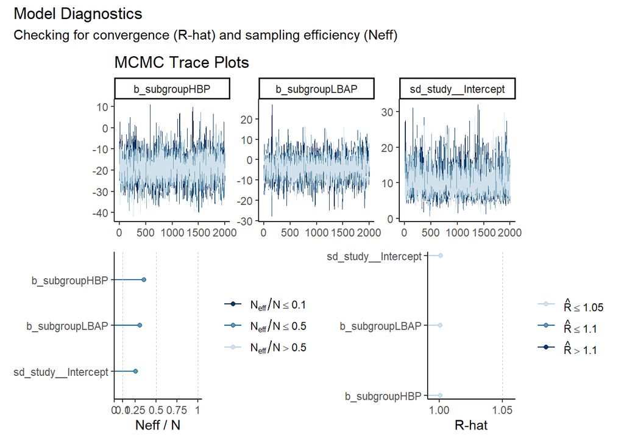

```r
# Diagnostic plots for the Bayesian model

my_pars <- c("b_subgroupHBP", "b_subgroupLBAP", "sd_study__Intercept")

# Create the individual diagnostic components

# TOP: Trace Plots (the "fuzzy caterpillars")
# Use 4 columns to match our diagnostic image
p_trace <- mcmc_trace(m1, pars = my_pars) +
  theme_classic() +
  theme(legend.position = "none") +
  ggtitle("MCMC Trace Plots")

# BOTTOM LEFT: Effective Sample Size (Neff / N)

neff_vals <- brms::neff_ratio(m1, pars = my_pars)
p_neff <- mcmc_neff(neff_vals) +
  theme_classic() +
  labs(x = "Neff / N")

# BOTTOM RIGHT: R-hat (Convergence diagnostic)

rhat_vals <- brms::rhat(m1, pars = my_pars)
p_rhat <- mcmc_rhat(rhat_vals) +
  theme_classic() +
  labs(x = "R-hat")

# Combine into the final layout
# The '/' stacks plots vertically; the '+' places them horizontally
final_diag_plot <- (p_trace) / (p_neff + p_rhat) +
  plot_layout(heights = c(1, 1.2)) +
  plot_annotation(
    title = "Model Diagnostics",
    subtitle = "Checking for convergence (R-hat) and sampling efficiency (Neff)"
  )

# 5. Display the plot
print(final_diag_plot)
```

#### “Point 3: Does Convergence Remain After Doubling the Number of Iterations?”

```r
# Fit the model

## Formula
mf =
  formula(yi | se(sei) ~ 0 + subgroup + (1|study))

priors =
  prior(normal(0, 24.5), class = "b") +
  prior(normal(0, 12.5), class = "sd")

m1_double =
  brm(
  data = d_MD,
  family = gaussian,

  formula = mf,
  prior = priors,

  control = list(adapt_delta = .97),
  backend = "cmdstanr", # faster
  cores = parallel::detectCores(),
  chains = 4,
  warmup = 4000, # double
  iter = 8000, # double
  seed = 123)
```

[output not shown]

[output cut: 283 more lines]

```
## Chain 1 Iteration: 7700 / 8000 [ 96%]  (Sampling)
## Chain 1 Iteration: 7800 / 8000 [ 97%]  (Sampling)
## Chain 1 Iteration: 7900 / 8000 [ 98%]  (Sampling)
## Chain 1 Iteration: 8000 / 8000 [100%]  (Sampling)
## Chain 2 Iteration: 7600 / 8000 [ 95%]  (Sampling)
## Chain 2 Iteration: 7700 / 8000 [ 96%]  (Sampling)
## Chain 2 Iteration: 7800 / 8000 [ 97%]  (Sampling)
## Chain 1 finished in 3.3 seconds.
## Chain 2 Iteration: 7900 / 8000 [ 98%]  (Sampling)
## Chain 2 Iteration: 8000 / 8000 [100%]  (Sampling)
## Chain 2 finished in 3.3 seconds.
##
## All 4 chains finished successfully.
## Mean chain execution time: 3.1 seconds.
## Total execution time: 3.5 seconds.
```

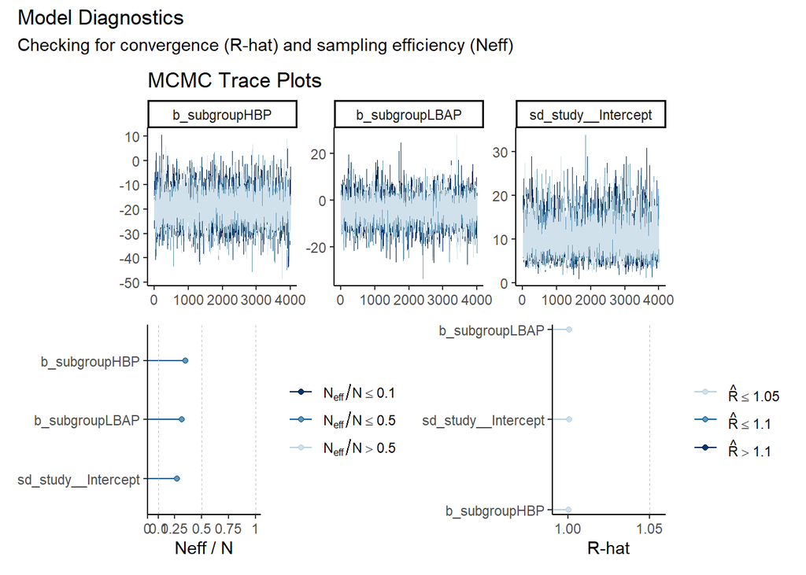

```r
my_pars <- c("b_subgroupHBP", "b_subgroupLBAP", "sd_study__Intercept")

# Create the individual diagnostic components

# TOP: Trace Plots (the "fuzzy caterpillars")
# Use 4 columns to match our diagnostic image
p_trace <- mcmc_trace(m1_double, pars = my_pars) +
  theme_classic() +
  theme(legend.position = "none") +
  ggtitle("MCMC Trace Plots")

# BOTTOM LEFT: Effective Sample Size (Neff / N)

neff_vals <- brms::neff_ratio(m1_double, pars = my_pars)
p_neff <- mcmc_neff(neff_vals) +
  theme_classic() +
  labs(x = "Neff / N")

# BOTTOM RIGHT: R-hat (Convergence diagnostic)

rhat_vals <- brms::rhat(m1_double, pars = my_pars)
p_rhat <- mcmc_rhat(rhat_vals) +
  theme_classic() +
  labs(x = "R-hat")

# Combine into the final layout
# The '/' stacks plots vertically; the '+' places them horizontally
final_diag_plot_double <- (p_trace) / (p_neff + p_rhat) +
  plot_layout(heights = c(1, 1.2)) +
  plot_annotation(
    title = "Model Diagnostics",
    subtitle = "Checking for convergence (R-hat) and sampling efficiency (Neff)"
  )

# Display the plot
print(final_diag_plot_double)
```

#### “Point 4: Does the Histogram Have Enough Information?”

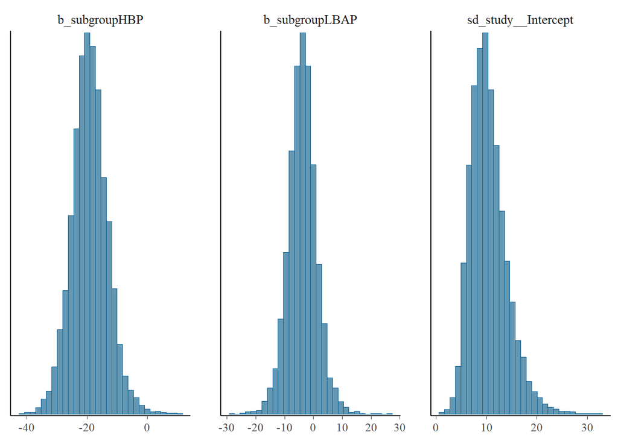

```r
mcmc_hist(m1, pars = c("b_subgroupHBP", "b_subgroupLBAP", "sd_study__Intercept"))
```

#### “Point 5: Do the Chains Exhibit a Strong Degree of Autocorrelation?”

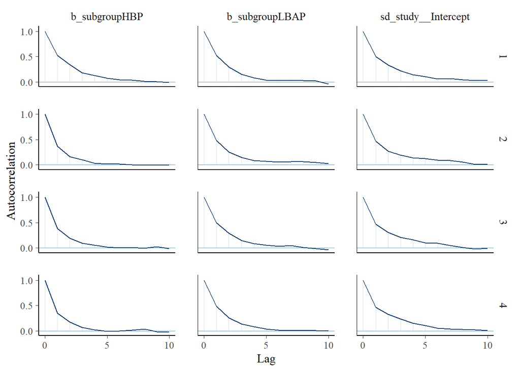

```r
mcmc_acf(m1,
         c("b_subgroupHBP", "b_subgroupLBAP", "sd_study__Intercept"),
         lags = 10)
```

#### “Point 6: Does the Posterior Distribution Make Substantive Sense?”

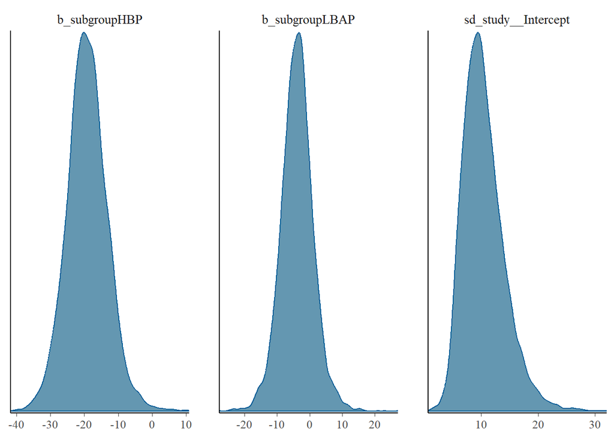

```r
mcmc_dens(m1, pars = c("b_subgroupHBP", "b_subgroupLBAP", "sd_study__Intercept"))
```

Posterior predictive check

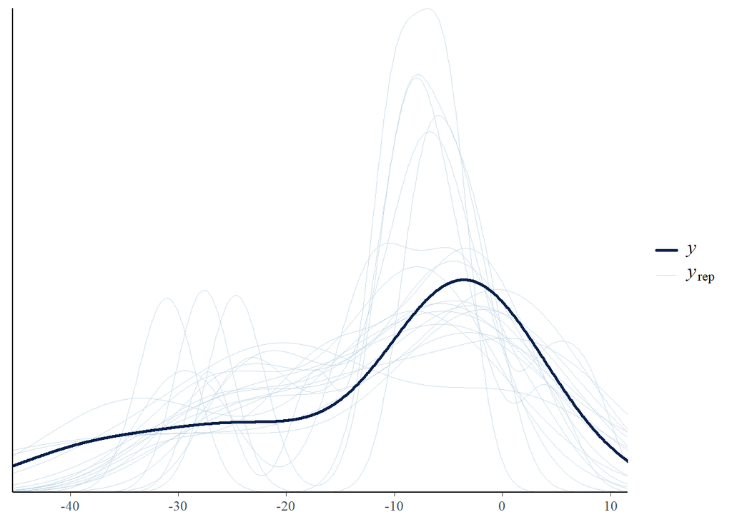

```r
pp_check(m1, ndraws = 20)
```

#### “Point 7: Do Different Specifications of the Multivariate Variance Priors Influence the Results?”

Not applicable.

#### “Point 8: Is There a Notable Effect of the Prior When Compared With Noninformative Priors?”

Here, we will fit models with different combinations of priors. For each parameter ($\alpha$ and $\tau$), we will use three different types of prior:

1. Weakly-informative
2. Vague
3. Skeptical

Notably, we used weakly-informative priors for all of the parameters in our main model.

Here are the distributions used for $\alpha$:

- Weakly-informative: $\operatorname{Normal}(0, 24.5^2)$
- Vague: $\operatorname{Normal}(0, 50^2)$
- skeptical: $\operatorname{Normal}(0, 12^2)$

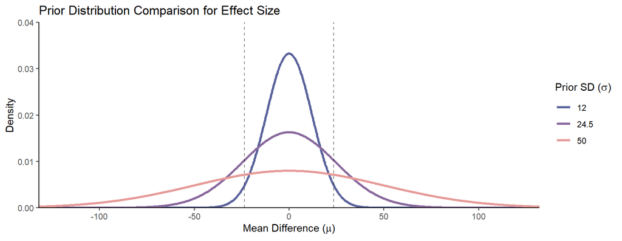

```r
# SD values for Mu Priors
sd_w = 24.5
sd_v = 50
sd_s = 12

# 95% CI boundaries for vertical lines
twosd_w = sd_w * 1.96
twosd_v = sd_v * 1.96
twosd_s = sd_s * 1.96

ggplot(data = data.frame(x = c(-150, 150)), aes(x)) +

  # Normal(0, 12) - The most "Skeptical"
  stat_function(fun = dnorm, n = 1000,
                args = list(mean = 0, sd = sd_s), size = 1.2,
                aes(colour = "12")) +

  # Normal(0, 24.5) - Medium width
  stat_function(fun = dnorm, n = 1000,
                args = list(mean = 0, sd = sd_w), size = 1.2,
                aes(colour = "24.5")) +

  # Normal(0, 50) - Very flat (Weakly Informative)
  stat_function(fun = dnorm, n = 1000,
                args = list(mean = 0, sd = sd_v), size = 1.2,
                aes(colour = "50")) +

  # Manual Colors
  scale_colour_manual(name = TeX("Prior SD ($\\sigma$)"),
                      values = pnw_palette("Starfish", 3)) +

  # Reference lines for the 95% CI of the narrowest and medium priors
  geom_vline(xintercept = c(-twosd_s, twosd_s), linetype = 2, alpha = 0.5) +

  # Y-Axis Scale (Adjusted for the peak of SD=12 which is ~0.033)
  scale_y_continuous(limits = c(0, 0.04), expand = c(0, 0)) +

  # X-Axis Scale (Adjusted to show the full width of the priors)
  scale_x_continuous(breaks = seq(-150, 150, 50)) +

  # CRITICAL: coord_cartesian must be wide enough to see the curves
  coord_cartesian(xlim = c(-120, 120)) +

  labs(x = TeX("Mean Difference ($\\mu$)"),
       y = "Density",
       title = "Prior Distribution Comparison for Effect Size") +
  theme_classic() +
  theme(legend.position = "right")
```

```r
# Using our defined values
sd_w = 24.5
sd_v = 50
sd_s = 12

tibble(
  "Prior" = c("Weakly-Informative", "Vague", "Skeptical"),
  Mean = 0,
  "SD" = c(sd_w, sd_v, sd_s)
) %>%
  mutate(

    "Lower 95% CI" = round(Mean - 1.96 * SD, 1),
    "Upper 95% CI" = round(Mean + 1.96 * SD, 1),
    "95% CI Interval" = str_c("[", `Lower 95% CI`, ", ", `Upper 95% CI`, "]")
  ) %>%
  select(Prior, Mean, SD, `95% CI Interval`) %>%
  gt() %>%
  cols_align(
    align = "center",
    columns = everything()
  ) %>%
  cols_align(
    align = "left",
    columns = "Prior"
  ) %>%
  tab_spanner(label = "Normal Prior Parameters",
              columns = c("Mean", "SD")) %>%
  tab_spanner(label = "Prior Predicted Range (MD)",
              columns = c("95% CI Interval"))
```

| Prior | Normal Prior Parameters Mean | Normal Prior Parameters SD | Prior Predicted Range (MD) 95% CI Interval |
| --- | --- | --- | --- |
| Weakly-Informative | 0 | 24.5 | [-48, 48] |
| Vague | 0 | 50.0 | [-98, 98] |
| Skeptical | 0 | 12.0 | [-23.5, 23.5] |

Here are the distributions used for $\tau$:

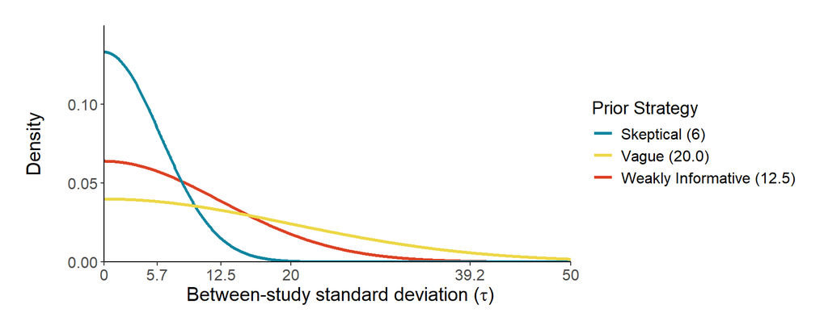

```r
sd_w_tau = 12.5 # Weakly Informative
sd_s_tau = 6 # skeptical
sd_v_tau = 20.0 # Vague



# Plotting
ggplot(data = data.frame(x = c(0, 50)), aes(x)) +

  # Weakly Informative: Half-Normal(12.5)
  stat_function(fun = dhnorm, n = 1000,
                args = list(sigma = sd_w_tau), size = 1.2,
                aes(colour = "Weakly Informative (12.5)")) +

  # Informative: Half-Normal(6)
  stat_function(fun = dhnorm, n = 1000,
                args = list(sigma = sd_s_tau), size = 1.2,
                aes(colour = "Skeptical (6)")) +

  # Vague: Half-Normal(20.0)
  stat_function(fun = dhnorm, n = 1000,
                args = list(sigma = sd_v_tau), size = 1.2,
                aes(colour = "Vague (20.0)")) +

  # Aesthetic Mapping
  scale_colour_manual("Prior Strategy",
                      values = pnw_palette("Bay", 3, type = "discrete")) +

  # Axis Scaling
  scale_y_continuous(expand = c(0, 0), limits = c(0, 0.15)) +
  scale_x_continuous(breaks = c(0, 5.67, 12.5, 20, 39.2, 50),
                     labels = function(x) round(as.numeric(x), 1),
                     expand = c(0, 0)) +

  coord_cartesian(xlim = c(0, 50)) +

  labs(x = TeX("\n Between-study standard deviation ($\\tau$)"),
       y = "Density\n") +
  theme_classic() +
  theme(
    plot.margin = margin(20, 20, 10, 20),
    axis.text = element_text(size = 12),
    axis.title = element_text(size = 15),
    legend.position = 'right',
    legend.title = element_text(size = 14),
    legend.text = element_text(size = 12)
  )
```

As mentioned above, we used all weakly-informative priors for our main model (already fitted). Now, we will fit two more models:

1. Using vague priors
2. Using informative priors

```r
## Priors

priors_list <- c("b_subgroupHBP", "b_subgroupLBAP", "sd_study__Intercept")
# alpha
alpha_vague =  prior(normal(0, 50), class = "b")
alpha_skeptical =  prior(normal(0, 12), class = "b")


tau_vague = prior(normal(0, 20), class = "sd", group = "study")
tau_skeptical = prior(normal(0, 6), class = "sd", group = "study")

# Put them all together in every possible combination, 1 line per model

priors_list <- list(

  # All vague
  c(alpha_vague, tau_vague),
  # All informative
  c(alpha_skeptical, tau_skeptical)
  )


### Create list to store fits
sensitivity_models = list()
#
### Store the main model
#
sensitivity_models[[1]] = m1
##
labs = data.frame(x = c("Weakly informative", "Vague", "Skeptical"))
# #


# We use seq_along to ensure the loop iterates correctly
for (i in seq_along(priors_list)) {

  # k is the index in sensitivity_models (2 and 3)
  k = i + 1

  print(paste("Running sensitivity model:", labs$x[k]))

  # Re-fit using update() based on am1
  sensitivity_models[[k]] <- update(m1,
                                    prior = priors_list[[i]],
                                    cores = parallel::detectCores(),
                                    chains = 4,
                                    control = list(adapt_delta = .97),
                                    backend = "cmdstanr",
                                    seed = 123,
                                    refresh = 0) # Suppress excessive output
}


names(sensitivity_models) <- labs$x
```

P.S.: The diagnostics plots of these two models will be shown in the end of this document.

Let’s visualize the prior and posterior distributions (constructed by the samples stored in each model object).

```r
# PREPARE THE MODELS

names(sensitivity_models) <- c("Weakly Informative", "Vague", "Skeptical")

# EXTRACT OR SIMULATE PRIOR DRAWS

n_sim <- 8000

# For Population Effects (beta)
weakly_prior <- tibble("Weakly Informative" = rnorm(n_sim, 0, 24.5))
vague_prior  <- tibble("Vague" = rnorm(n_sim, 0, 50))
skeptical_prior <- tibble("Skeptical" = rnorm(n_sim, 0, 12))

priors <- bind_cols(weakly_prior, vague_prior, skeptical_prior) %>%
  pivot_longer(1:3) %>%
  mutate(name = factor(name, levels = c("Weakly Informative", "Vague", "Skeptical"))) %>%
  ggplot(aes(value)) +
  stat_halfeye(point_interval = median_hdi, .width = .95,
               fill = "#347178", slab_color = "grey92", outline_bars = TRUE) +
  scale_x_continuous(breaks = seq(-100, 100, 50)) +
  coord_cartesian(x = c(-120, 120)) +
  labs(x = latex2exp::TeX("$\\beta$ (Prior Mean Difference)"), y = "Density\n") +
  theme(
    strip.background = element_rect(fill = "#E4E6E7"),
    strip.text.x = element_text(size = 12),
    axis.ticks.x = element_blank(),
    axis.ticks.y = element_blank(),
    axis.text.x = element_text(size = 12),
    axis.title.x = element_text(size = 14),
    axis.text.y = element_blank(),
    panel.background = element_blank(),
    panel.grid.major.x = element_line(color = "gray80", linewidth = 0.3),
    legend.position = 'none',
    plot.margin = margin(20, 20, 20, 20)
  ) +
  facet_wrap(~name, ncol = 1)

# EXTRACT POSTERIOR DRAWS
weakly_posterior <- sensitivity_models[["Weakly Informative"]] %>%
  tidy_draws() %>% select(b_subgroupHBP, b_subgroupLBAP) %>%
  rename("Weakly Informative [HBP]" = b_subgroupHBP,
         "Weakly Informative [LBAP]" = b_subgroupLBAP)

vague_posterior <- sensitivity_models[["Vague"]] %>%
  tidy_draws() %>% select(b_subgroupHBP, b_subgroupLBAP) %>%
  rename("Vague [HBP]" = b_subgroupHBP,
         "Vague [LBAP]" = b_subgroupLBAP)

skeptical_posterior <- sensitivity_models[["Skeptical"]] %>%
  tidy_draws() %>% select(b_subgroupHBP, b_subgroupLBAP) %>%
  rename("Skeptical [HBP]" = b_subgroupHBP,
         "Skeptical [LBAP]" = b_subgroupLBAP)

posteriors <- bind_cols(weakly_posterior, vague_posterior, skeptical_posterior) %>%
  pivot_longer(1:last_col()) %>%
  ggplot(aes(value)) +
  stat_halfeye(point_interval = median_hdi, .width = .95,
               fill = "#605A91", slab_color = "grey92", outline_bars = TRUE) +
  scale_x_continuous(breaks = seq(-40, 20, 10)) +
  geom_vline(xintercept = 0, linetype = "dashed", color = "gray80") +
  coord_cartesian(x = c(-45, 25)) +
  labs(x = latex2exp::TeX("$\\beta$ (Posterior Mean Difference)"), y = "Density\n") +
  theme(
    strip.background = element_rect(fill = "#E4E6E7"),
    strip.text.x = element_text(size = 12),
    axis.ticks.x = element_blank(),
    axis.ticks.y = element_blank(),
    axis.text.x = element_text(size = 12),
    axis.title.x = element_text(size = 14),
    axis.text.y = element_blank(),
    panel.background = element_blank(),
    panel.grid.major.x = element_line(color = "gray80", linewidth = 0.3),
    legend.position = 'none',
    plot.margin = margin(20, 20, 20, 20)
  ) +
  facet_wrap(~name, ncol = 2)

# TAU (HETEROGENEITY) PRIORS

n_sim <- 8000

priors_tau <- bind_cols(
  tibble("Weakly Informative" = abs(rnorm(n_sim, 0, 12.5))),
  tibble("Vague" = abs(rnorm(n_sim, 0, 20))),
  tibble("Skeptical" = abs(rnorm(n_sim, 0, 6)))
) %>%
  pivot_longer(cols = 1:3) %>%
  mutate(name = factor(name, levels = c("Weakly Informative", "Vague", "Skeptical"))) %>%
  ggplot(aes(x = value)) +
  stat_halfeye(fill = "#9B5446", slab_color = "grey92", outline_bars = TRUE) +
  scale_x_continuous(breaks = seq(0, 50, 10)) +
  coord_cartesian(xlim = c(0, 50)) +
  labs(x = latex2exp::TeX("Prior between-study standard deviation ($\\tau$)"),
       y = "Density\n") +
  theme(
    strip.background = element_rect(fill = "#E4E6E7"),
    strip.text.x = element_text(size = 12),
    axis.ticks.y = element_blank(),
    axis.text.x = element_text(size = 12),
    axis.title.x = element_text(size = 14),
    axis.text.y = element_blank(),
    panel.background = element_blank(),
    panel.grid.major.x = element_line(color = "gray80", linewidth = 0.3),
    legend.position = 'none',
    plot.margin = margin(20, 20, 20, 20)
  ) +
  facet_wrap(~name, ncol = 1)

# TAU (HETEROGENEITY) POSTERIORS

posteriors_tau <- bind_cols(
  sensitivity_models[["Weakly Informative"]] %>% tidy_draws() %>%
    select(sd_study__Intercept) %>% rename("Weakly Informative" = sd_study__Intercept),
  sensitivity_models[["Vague"]] %>% tidy_draws() %>%
    select(sd_study__Intercept) %>% rename("Vague" = sd_study__Intercept),
  sensitivity_models[["Skeptical"]] %>% tidy_draws() %>%
    select(sd_study__Intercept) %>% rename("Skeptical" = sd_study__Intercept)
) %>%
  pivot_longer(cols = 1:3) %>%
  mutate(name = factor(name, levels = c("Weakly Informative", "Vague", "Skeptical"))) %>%
  ggplot(aes(x = value)) +
  stat_halfeye(fill = "#9B5446", slab_color = "grey92", outline_bars = TRUE) +
  scale_x_continuous(breaks = seq(0, 30, 5)) +
  coord_cartesian(xlim = c(0, 35)) +
  labs(x = latex2exp::TeX("Posterior between-study standard deviation ($\\tau$)"),
       y = "Density\n") +
  theme(
    strip.background = element_rect(fill = "#E4E6E7"),
    strip.text.x = element_text(size = 12),
    axis.ticks.y = element_blank(),
    axis.text.x = element_text(size = 12),
    axis.title.x = element_text(size = 14),
    axis.text.y = element_blank(),
    panel.background = element_blank(),
    panel.grid.major.x = element_line(color = "gray80", linewidth = 0.3),
    legend.position = 'none',
    plot.margin = margin(20, 20, 20, 20)
  ) +
  facet_wrap(~name, ncol = 1)
```

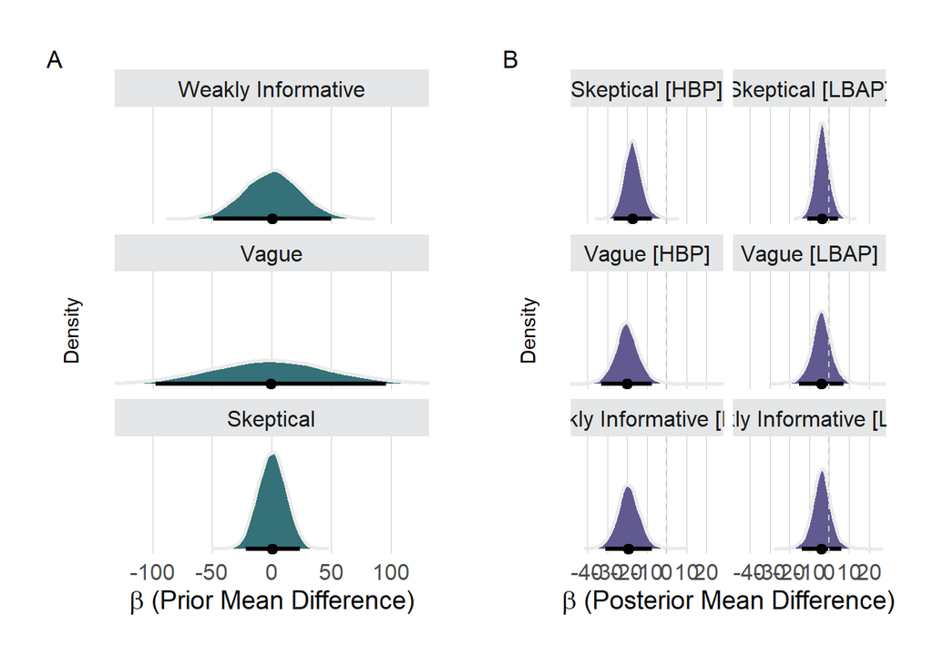

```r
(priors + posteriors) + plot_annotation(tag_levels = "A")
```

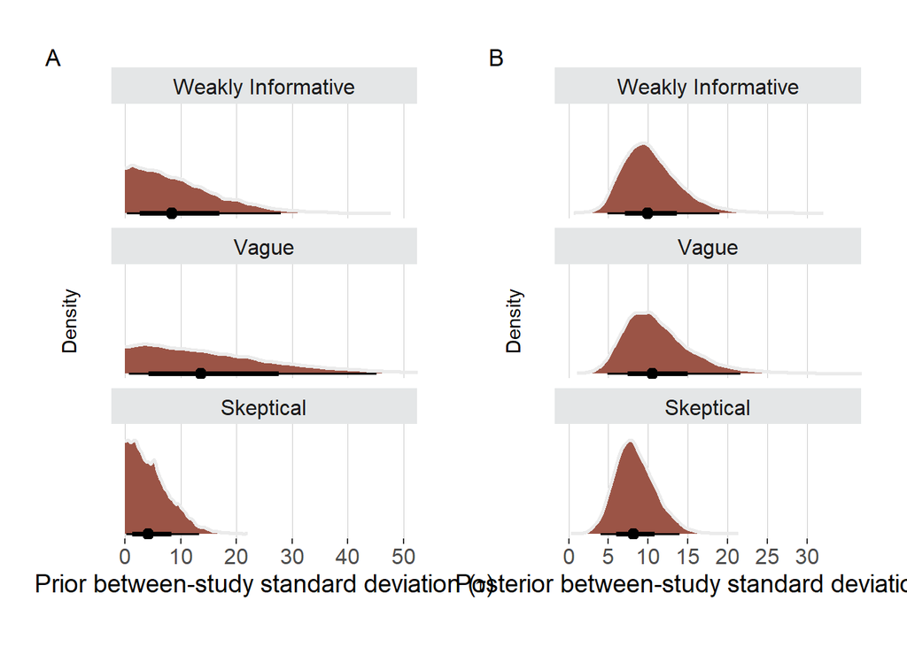

```r
(priors_tau + posteriors_tau) + plot_annotation(tag_levels = "A")
```

#### “Point 9: Are the Results Stable From a Sensitivity Analysis?”

We did not fit models “adjusting the entire prior distribution (i.e., using a completely different prior distribution than before) or adjusting hyperparameters upward and downward and reestimating the model with these varied priors.”

#### Extra Diagnostic plots

On the models shown in “Point 8: Is There a Notable Effect of the Prior When Compared With Noninformative Priors?”

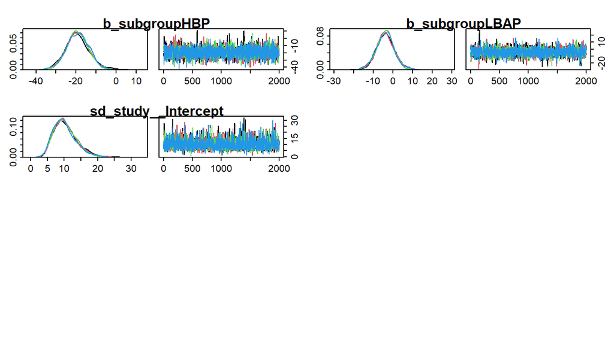

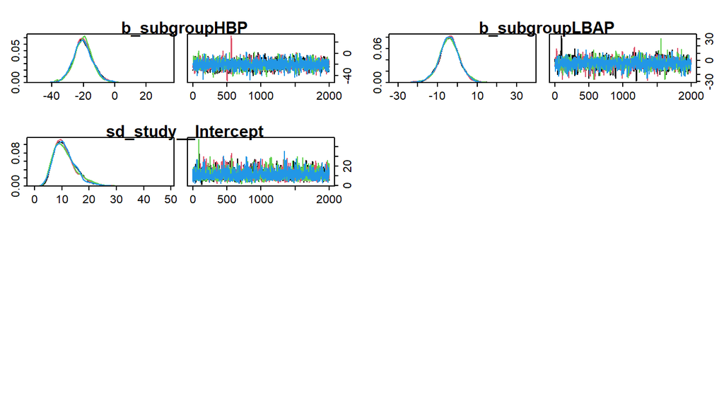

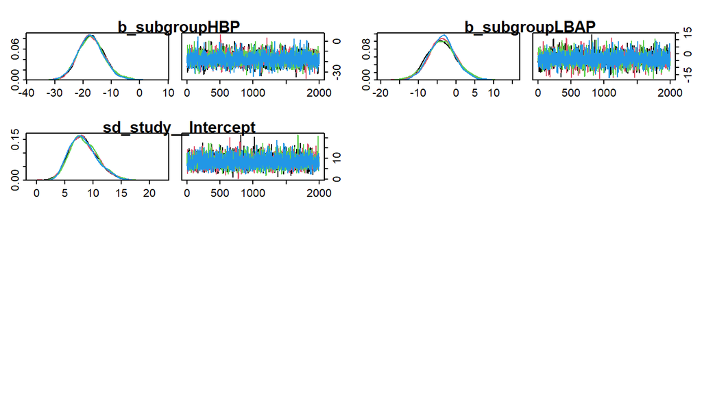

```r
# DEFINE CUSTOM DIAGNOSTIC FUNCTION

diag_plot <- function(model, pars_list, ncol_trace = 4) {

  # Convert brms object to mcmc.list for compatibility with diagnostic tools
  model_mcmc <- brms::as.mcmc(model)

  # Determine layout based on parameter count
  n_params <- length(pars_list)
  playout <- if(n_params <= 2) "2x1" else "4x2"

  # Generate the grid of trace and density plots
  postpack::diag_plots(post = model_mcmc, params = pars_list, layout = playout)
}

# Ensure the model list is named for the loops
names(sensitivity_models) <- c("Weakly Informative", "Vague", "Skeptical")


# Loop through each sensitivity model to verify convergence
for (i in seq_along(sensitivity_models)) {
  current_name <- names(sensitivity_models)[i]

  # Generate the trace/density grid
  diag_plot(model = sensitivity_models[[i]],
            pars_list = c("b_subgroupHBP", "b_subgroupLBAP", "sd_study__Intercept"),
            ncol_trace = 4)

  # Add a title label at the bottom of the plot output
  grid::grid.text(paste("Model:", current_name), 0.5, 0.02,
                  gp=grid::gpar(cex=1.2, fontface="bold"))
}
```

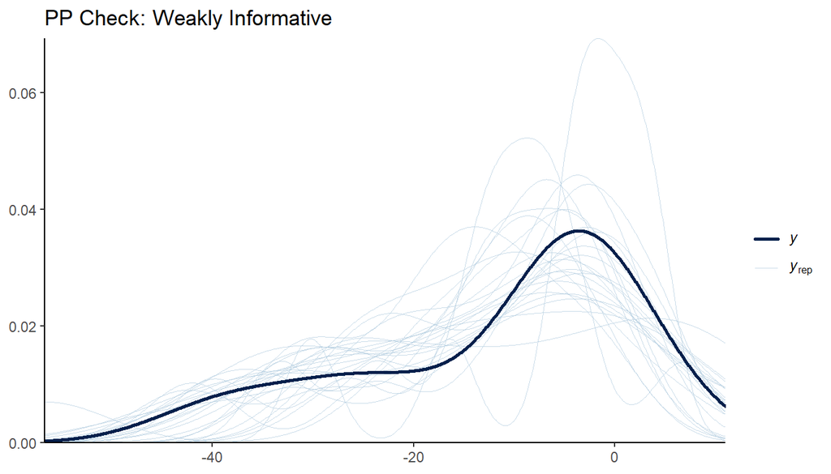

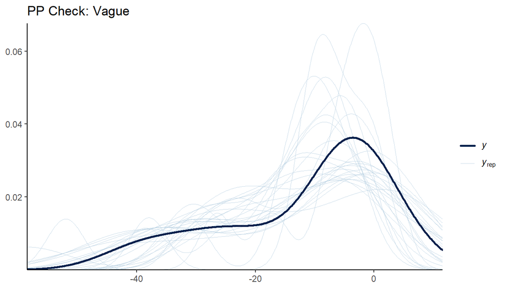

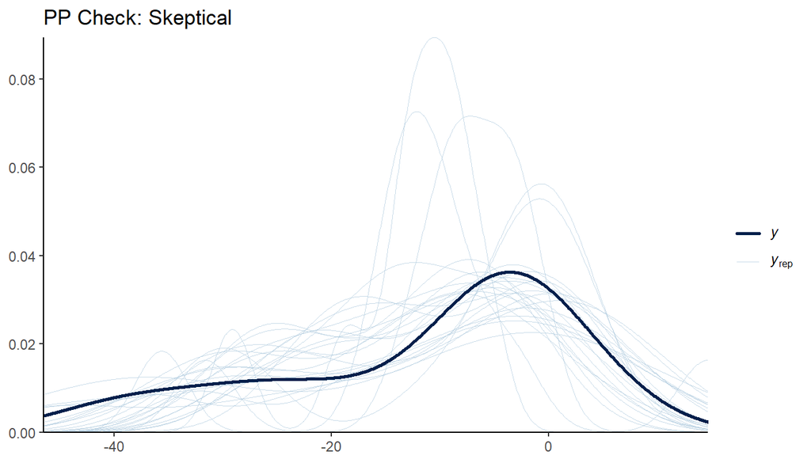

```r
# POSTERIOR PREDICTIVE CHECKS (PPC)
for (i in seq_along(sensitivity_models)) {
  p = pp_check(sensitivity_models[[i]], ndraws = 25) +
      theme_classic() +
      ggtitle(paste("PP Check:", names(sensitivity_models)[i]))

  print(p)
}
```

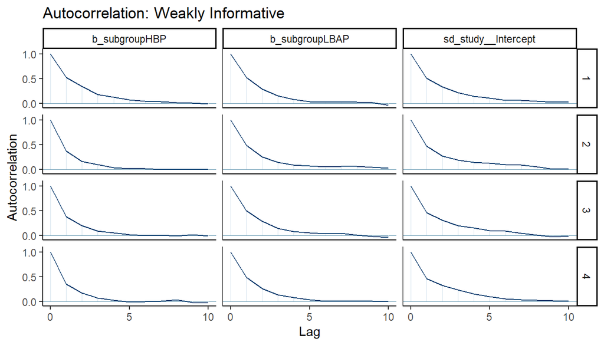

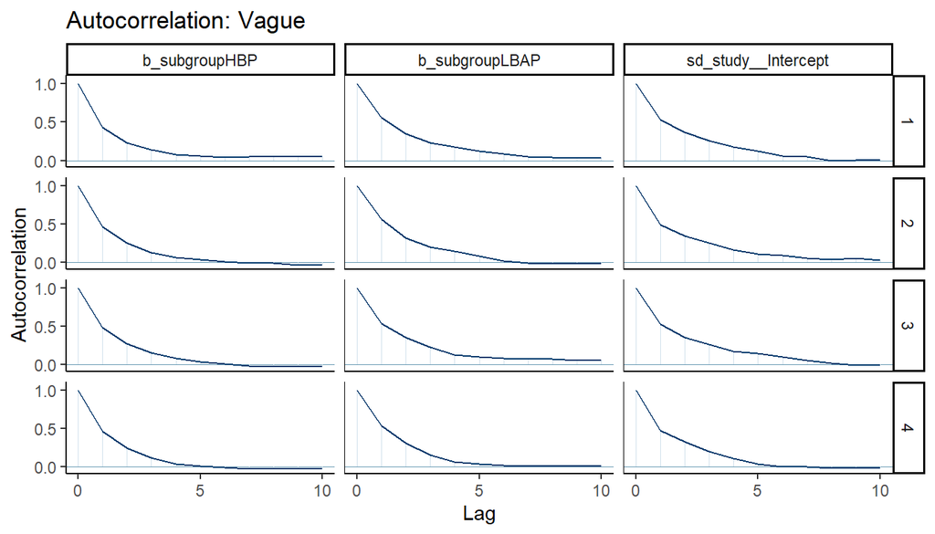

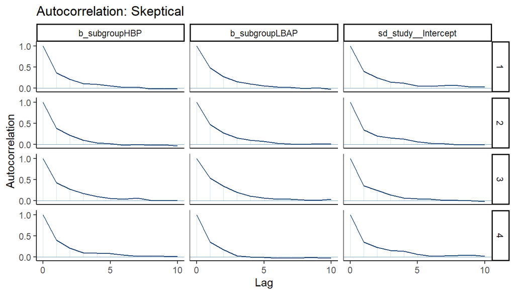

```r
# AUTOCORRELATION (ACF) PLOTS

for (i in seq_along(sensitivity_models)) {
  p = mcmc_acf(sensitivity_models[[i]],
               pars = c("b_subgroupHBP", "b_subgroupLBAP", "sd_study__Intercept"),
               lags = 10) +
      theme_classic() +
      ggtitle(paste("Autocorrelation:", names(sensitivity_models)[i]))

  print(p)
}
```

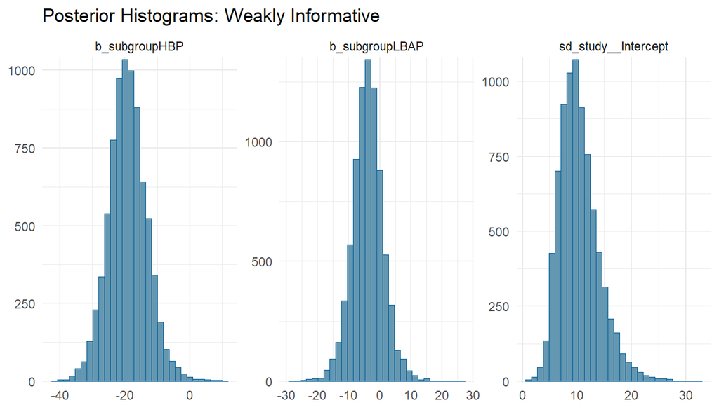

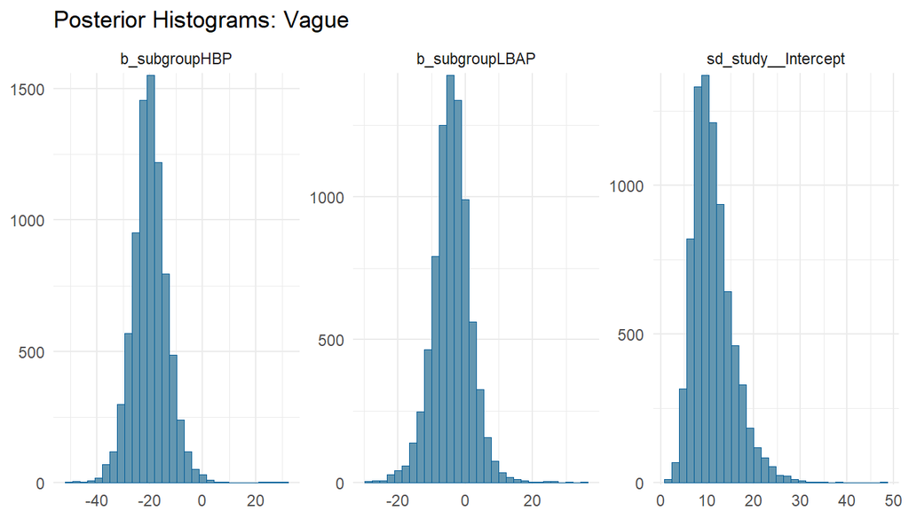

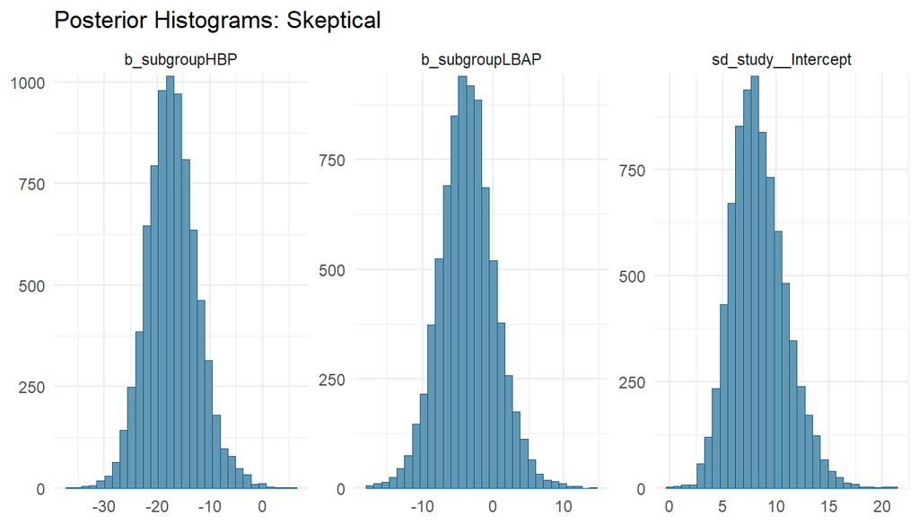

```r
# Quick visual check of the parameter distributions
for (i in seq_along(sensitivity_models)) {
  p = mcmc_hist(sensitivity_models[[i]],
                pars = c("b_subgroupHBP", "b_subgroupLBAP", "sd_study__Intercept")) +
      theme_minimal() +
      ggtitle(paste("Posterior Histograms:", names(sensitivity_models)[i]))

  print(p)
}
```

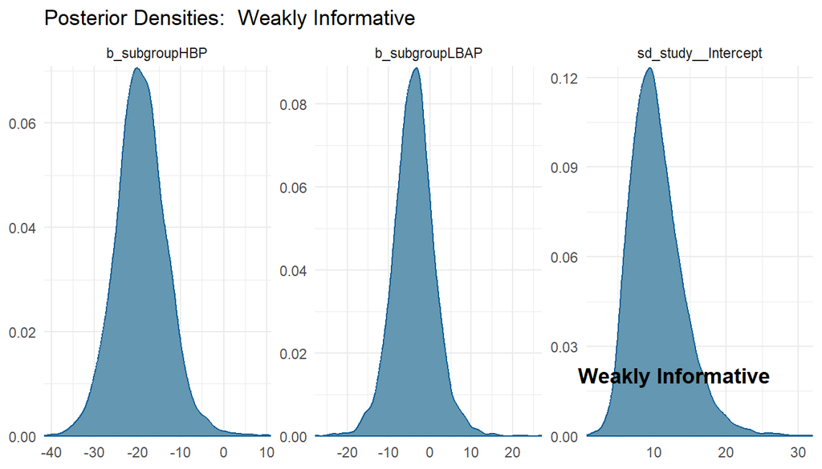

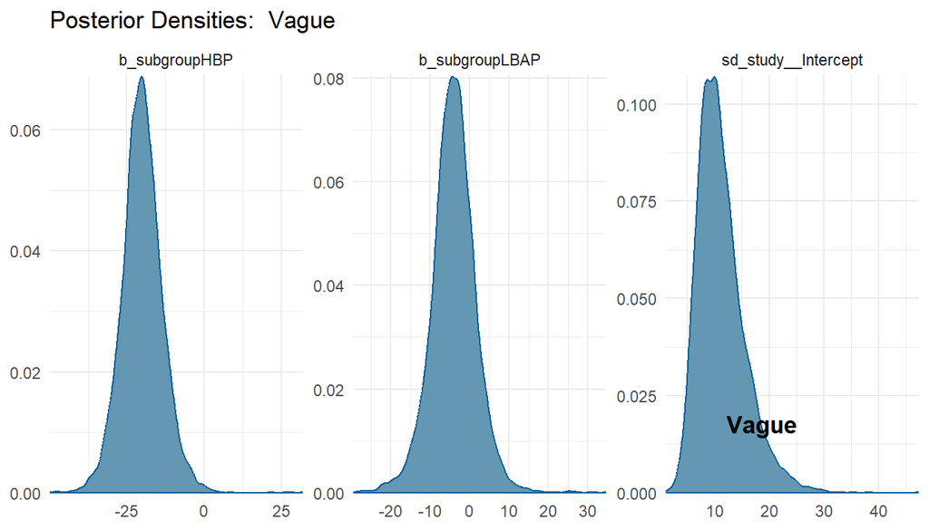

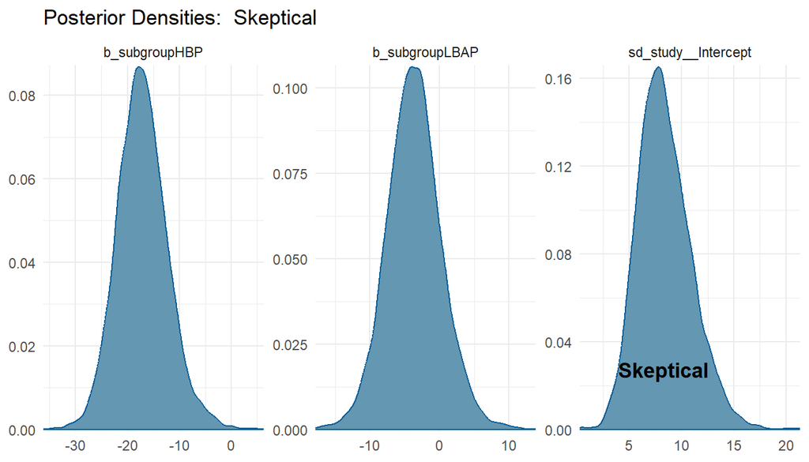

```r
# DENSITY OVERLAY LOOP


labs_df <- data.frame(x = names(sensitivity_models))

for (i in 1:nrow(labs_df)) {


  # Parameters updated for HBP and LBAP
  p = mcmc_dens(sensitivity_models[[i]],
                pars = c("b_subgroupHBP", "b_subgroupLBAP", "sd_study__Intercept")) +
      theme_minimal() +
      labs(title = paste("Posterior Densities: ", labs_df$x[i]))

  # Display plot
  print(p)

  # Add the floating text label
  lab_text = labs_df$x[i]
  grid::grid.text(lab_text, 0.82, .2, gp = grid::gpar(cex = 1.1, fontface = "bold", col = "black"))
}
```